# Úkol 4 – Pokročilá neuronová síť (CNN) pro predikci spolehlivosti kvantových obvodů

Cílem tohoto notebooku je navrhnout, natrénovat a vyhodnotit **konvoluční neuronovou síť (CNN)** pro regresi cílové proměnné `reliability` a porovnat ji s klasickými ML modely z předchozích úkolů.

**Dataset:** `thesis_production_125k_v1` – vzorková sada uložená v `data/hw2/`  
**Cílová proměnná:** `reliability` ∈ [0, 1]  
**Typ úlohy:** Regrese  
**Architektura:** 1D Convolutional Neural Network se sémantickým seskupením příznaků  
**Framework:** PyTorch

## 1. Motivace – proč CNN na tabulková data?

Konvoluční neuronové sítě (CNN) jsou tradičně spojovány se zpracováním obrazu, kde využívají prostorovou lokalitu pixelů. U tabulkových dat neexistuje přirozená prostorová struktura – pořadí sloupců je libovolné.

Přesto existuje legitimní důvod CNN na tento dataset aplikovat: **příznaky mají sémantickou strukturu**. Celkem 46 příznaků lze rozdělit do tří skupin:

| Skupina | Počet příznaků | Popis |
| --- | --- | --- |
| Původní obvod (`original_*`) | 17 | Topologie obvodu před transpilací |
| Transpilovaný obvod | 17 | Topologie po transpilaci na konkrétní hardware |
| Hardwarový šum / kalibrace | 12 | Chybovosti hradel, dekoherenční časy, readout error |

1D konvoluce nad příznaky **v rámci každé skupiny** může zachytit lokální vzory (např. vztah mezi `num_cx` a `entanglement_density` v transpilované skupině), které plně propojený model zachycuje jen přes globální váhy.

### Architektura: Multi-Branch 1D CNN

Náš model má **tři paralelní konvoluční větve**, jednu pro každou skupinu příznaků. Každá větev nezávisle extrahuje lokální vzory, načež se jejich reprezentace spojí a projdou plně propojenými vrstvami pro finální predikci.

Pro srovnání trénujeme i **jednoduchou MLP síť** (baseline neuronová síť bez konvolucí) a porovnáváme s nejlepším klasickým modelem z HW3 (Náhodný les, MAE ≈ 0.044).

```
Všechny závislosti jsou dostupné.
```

```
PyTorch 2.12.1+cpu, zařízení: cpu
Import dokončen.
```

## 2. Načtení dat a předzpracování

Používáme stejné rozdělení train/validation/test jako v HW2 a HW3. Preprocessing (mediánová imputace + standardizace) je fitován **pouze na trénovací sadě** – prevence data leaku.

```
Train:      20,000 řádků
Validation:  2,500 řádků
Test:        2,500 řádků
Počet povolených příznaků: 46
```

```
Tvar vstupu po předzpracování: (20000, 46)
Chybějící hodnoty po imputaci: 0
```

## 3. Sémantické skupiny příznaků

Pro CNN seskupíme příznaky podle jejich významu. Konvoluční filtry budou hledat lokální vzory **v rámci** každé skupiny.

```
Skupina 1 – Původní obvod:     17 příznaků
Skupina 2 – Transpilovaný obvod: 17 příznaků
Skupina 3 – Hardwarový šum:     12 příznaků
Celkem pokryto: 46 / 46
```

## 4. Definice architektury CNN

### 4.1 Multi-Branch 1D CNN

Architektura se skládá ze tří hlavních komponent:

1. **Konvoluční větve** – každá skupina příznaků je zpracována nezávislým 1D konvolučním blokem:
   - `Conv1d` → `BatchNorm1d` → `ReLU` → `Conv1d` → `BatchNorm1d` → `ReLU` → `AdaptiveAvgPool1d`
   - Kernel size = 3 zachycuje trojice sousedních příznaků v rámci skupiny
   - Padding = 1 zajistí, že výstup konvoluce má stejnou délku jako vstup
2. **Fúzní vrstva** – výstupy všech tří větví jsou zřetězeny do jednoho vektoru
3. **Regresní hlava** – plně propojené vrstvy s BatchNorm, ReLU a Dropout pro finální predikci

```
Vstup (46 příznaků)
  ├── Větev 1: original_* (17) → Conv1d blocks → pool → 128-dim
  ├── Větev 2: transpiled  (17) → Conv1d blocks → pool → 128-dim
  └── Větev 3: hardware    (12) → Conv1d blocks → pool → 128-dim
       │
       └── Concat (384-dim) → FC(128) → BN → ReLU → Dropout
                             → FC(64) → BN → ReLU → Dropout
                             → FC(1) → reliability
```

```
MultiBranchCNN(
  (branches): ModuleList(
    (0-2): 3 x ConvBranch(
      (conv): Sequential(
        (0): Conv1d(1, 32, kernel_size=(3,), stride=(1,), padding=(1,))
        (1): BatchNorm1d(32, eps=1e-05, momentum=0.1, affine=True, bias=True, track_running_stats=True)
        (2): ReLU()
        (3): Conv1d(32, 64, kernel_size=(3,), stride=(1,), padding=(1,))
        (4): BatchNorm1d(64, eps=1e-05, momentum=0.1, affine=True, bias=True, track_running_stats=True)
        (5): ReLU()
        (6): AdaptiveAvgPool1d(output_size=2)
      )
    )
  )
  (head): Sequential(
    (0): Linear(in_features=384, out_features=128, bias=True)
    (1): BatchNorm1d(128, eps=1e-05, momentum=0.1, affine=True, bias=True, track_running_stats=True)
    (2): ReLU()
    (3): Dropout(p=0.15, inplace=False)
    (4): Linear(in_features=128, out_features=64, bias=True)
    (5): BatchNorm1d(64, eps=1e-05, momentum=0.1, affine=True, bias=True, track_running_stats=True)
    (6): ReLU()
    (7): Dropout(p=0.15, inplace=False)
    (8): Linear(in_features=64, out_features=1, bias=True)
  )
)

Celkem parametrů: 77,569
Trénovatelných:   77,569
```

### 4.2 Baseline MLP (pro srovnání)

Jednoduchá plně propojená síť bez konvolucí – slouží k ověření, zda konvoluční struktura přináší výhodu oproti standardnímu feed-forward přístupu.

```
MLP parametrů: 14,721
```

## 5. Trénovací smyčka s Early Stopping

Trénujeme obě sítě s identickými podmínkami:

- **Optimizer:** AdamW (lr=1e-3, weight_decay=1e-4)
- **Loss:** MSE (Mean Squared Error)
- **Batch size:** 256
- **Early stopping:** zastavíme, pokud se validační MAE nezlepší po 15 epochách
- **Max epoch:** 150

### 5.1 Trénování Multi-Branch CNN

```
Trénuji Multi-Branch CNN...
```

```
  Epocha   1 | loss=0.108290 | val_mae=0.09303 | val_r2=0.5545 | lr=1.0e-03 *
```

```
  Epocha   2 | loss=0.041064 | val_mae=0.07879 | val_r2=0.6589 | lr=1.0e-03 *
```

```
  Epocha   3 | loss=0.031866 | val_mae=0.07834 | val_r2=0.6519 | lr=1.0e-03 *
```

```
  Epocha   4 | loss=0.025859 | val_mae=0.07710 | val_r2=0.6721 | lr=1.0e-03 *
```

```
  Epocha   5 | loss=0.022423 | val_mae=0.06731 | val_r2=0.7092 | lr=1.0e-03 *
```

```
  Epocha   7 | loss=0.018638 | val_mae=0.06690 | val_r2=0.7132 | lr=1.0e-03 *
```

```
  Epocha  10 | loss=0.015585 | val_mae=0.06357 | val_r2=0.7371 | lr=1.0e-03 *
```

```
  Epocha  11 | loss=0.015368 | val_mae=0.06342 | val_r2=0.7284 | lr=1.0e-03 *
```

```
  Epocha  13 | loss=0.014213 | val_mae=0.06222 | val_r2=0.7413 | lr=1.0e-03 *
```

```
  Epocha  16 | loss=0.013019 | val_mae=0.06215 | val_r2=0.7371 | lr=1.0e-03 *
```

```
  Epocha  17 | loss=0.012745 | val_mae=0.06053 | val_r2=0.7522 | lr=1.0e-03 *
```

```
  Epocha  19 | loss=0.012285 | val_mae=0.05928 | val_r2=0.7676 | lr=1.0e-03 *
```

```
  Epocha  20 | loss=0.011834 | val_mae=0.05685 | val_r2=0.7714 | lr=1.0e-03 *
```

```
  Epocha  22 | loss=0.011226 | val_mae=0.05670 | val_r2=0.7728 | lr=1.0e-03 *
```

```
  Epocha  25 | loss=0.010452 | val_mae=0.05591 | val_r2=0.7766 | lr=1.0e-03 *
```

```
  Epocha  30 | loss=0.009691 | val_mae=0.06217 | val_r2=0.7535 | lr=1.0e-03
```

```
  Epocha  32 | loss=0.009185 | val_mae=0.05511 | val_r2=0.7828 | lr=1.0e-03 *
```

```
  Epocha  34 | loss=0.008957 | val_mae=0.05242 | val_r2=0.7991 | lr=1.0e-03 *
```

```
  Epocha  40 | loss=0.008412 | val_mae=0.05109 | val_r2=0.8129 | lr=1.0e-03 *
```

```
  Epocha  50 | loss=0.007225 | val_mae=0.04992 | val_r2=0.8148 | lr=5.0e-04 *
```

```
  Epocha  59 | loss=0.006653 | val_mae=0.04859 | val_r2=0.8236 | lr=2.5e-04 *
```

```
  Epocha  60 | loss=0.006690 | val_mae=0.04844 | val_r2=0.8250 | lr=2.5e-04 *
```

```
  Epocha  63 | loss=0.006431 | val_mae=0.04726 | val_r2=0.8285 | lr=2.5e-04 *
```

```
  Epocha  67 | loss=0.006397 | val_mae=0.04699 | val_r2=0.8326 | lr=2.5e-04 *
```

```
  Epocha  68 | loss=0.006278 | val_mae=0.04695 | val_r2=0.8305 | lr=2.5e-04 *
```

```
  Epocha  70 | loss=0.006347 | val_mae=0.05620 | val_r2=0.7976 | lr=2.5e-04
```

```
  Epocha  74 | loss=0.006272 | val_mae=0.04652 | val_r2=0.8340 | lr=2.5e-04 *
```

```
  Epocha  80 | loss=0.006283 | val_mae=0.04705 | val_r2=0.8305 | lr=2.5e-04
```

```
  Epocha  89 | loss=0.005721 | val_mae=0.04633 | val_r2=0.8324 | lr=1.3e-04 *
```

```
  Epocha  90 | loss=0.005759 | val_mae=0.04770 | val_r2=0.8291 | lr=1.3e-04
```

```
  Epocha  97 | loss=0.005518 | val_mae=0.04609 | val_r2=0.8353 | lr=1.3e-04 *
```

```
  Epocha 100 | loss=0.005694 | val_mae=0.04881 | val_r2=0.8241 | lr=1.3e-04
```

```
  Epocha 110 | loss=0.005281 | val_mae=0.04630 | val_r2=0.8322 | lr=6.3e-05
```

```
  Epocha 112 | loss=0.005271 | val_mae=0.04554 | val_r2=0.8358 | lr=6.3e-05 *
```

```
  Epocha 120 | loss=0.005211 | val_mae=0.04664 | val_r2=0.8338 | lr=6.3e-05
```

```
  Early stopping v epochě 127 (patience=15)
  Nejlepší validační MAE: 0.04554
Čas trénování CNN: 305.3s
```

### 5.2 Trénování Baseline MLP

```
Trénuji Baseline MLP...
```

```
  Epocha   1 | loss=0.189183 | val_mae=0.09903 | val_r2=0.5058 | lr=1.0e-03 *
```

```
  Epocha   2 | loss=0.047703 | val_mae=0.08077 | val_r2=0.6288 | lr=1.0e-03 *
```

```
  Epocha   3 | loss=0.039652 | val_mae=0.07885 | val_r2=0.6426 | lr=1.0e-03 *
```

```
  Epocha   5 | loss=0.029810 | val_mae=0.07833 | val_r2=0.6518 | lr=1.0e-03 *
```

```
  Epocha   6 | loss=0.026532 | val_mae=0.07516 | val_r2=0.6621 | lr=1.0e-03 *
```

```
  Epocha   7 | loss=0.023802 | val_mae=0.07223 | val_r2=0.6810 | lr=1.0e-03 *
```

```
  Epocha   8 | loss=0.022415 | val_mae=0.07031 | val_r2=0.6989 | lr=1.0e-03 *
```

```
  Epocha   9 | loss=0.020821 | val_mae=0.06963 | val_r2=0.6988 | lr=1.0e-03 *
```

```
  Epocha  10 | loss=0.019617 | val_mae=0.06629 | val_r2=0.7098 | lr=1.0e-03 *
```

```
  Epocha  14 | loss=0.016637 | val_mae=0.06534 | val_r2=0.7209 | lr=1.0e-03 *
```

```
  Epocha  20 | loss=0.014136 | val_mae=0.06342 | val_r2=0.7302 | lr=1.0e-03 *
```

```
  Epocha  23 | loss=0.013115 | val_mae=0.06298 | val_r2=0.7230 | lr=1.0e-03 *
```

```
  Epocha  26 | loss=0.012746 | val_mae=0.06088 | val_r2=0.7417 | lr=1.0e-03 *
```

```
  Epocha  30 | loss=0.012272 | val_mae=0.06012 | val_r2=0.7473 | lr=1.0e-03 *
```

```
  Epocha  32 | loss=0.011806 | val_mae=0.05941 | val_r2=0.7474 | lr=1.0e-03 *
```

```
  Epocha  35 | loss=0.011361 | val_mae=0.05723 | val_r2=0.7559 | lr=1.0e-03 *
```

```
  Epocha  40 | loss=0.011073 | val_mae=0.05786 | val_r2=0.7534 | lr=1.0e-03
```

```
  Epocha  42 | loss=0.010965 | val_mae=0.05662 | val_r2=0.7602 | lr=1.0e-03 *
```

```
  Epocha  46 | loss=0.010746 | val_mae=0.05553 | val_r2=0.7598 | lr=1.0e-03 *
```

```
  Epocha  50 | loss=0.010444 | val_mae=0.05580 | val_r2=0.7594 | lr=1.0e-03
```

```
  Epocha  60 | loss=0.009920 | val_mae=0.05554 | val_r2=0.7640 | lr=5.0e-04
```

```
  Early stopping v epochě 61 (patience=15)
  Nejlepší validační MAE: 0.05553
Čas trénování MLP: 28.1s
```

## 5.3 Experimenty s hyperparametry CNN

Systematicky testujeme vliv klíčových hyperparametrů na výkonnost Multi-Branch CNN. Měníme vždy jeden parametr oproti výchozí konfiguraci (conv=32, fc=128, dropout=0.15, lr=1e-3) a přidáváme dvě kombinované konfigurace.

| # | Konfigurace | conv_channels | fc_hidden | dropout | lr |
| --- | --- | --- | --- | --- | --- |
| 1 | Výchozí (baseline) | 32 | 128 | 0.15 | 1e-3 |
| 2 | Malá síť | 16 | 64 | 0.15 | 1e-3 |
| 3 | Velká síť | 64 | 256 | 0.15 | 1e-3 |
| 4 | Nízký dropout | 32 | 128 | 0.05 | 1e-3 |
| 5 | Vysoký dropout | 32 | 128 | 0.30 | 1e-3 |
| 6 | Pomalé učení | 32 | 128 | 0.15 | 5e-4 |
| 7 | Rychlé učení | 32 | 128 | 0.15 | 2e-3 |
| 8 | Velká + nízký drop | 64 | 256 | 0.10 | 5e-4 |

```
============================================================
A: Výchozí (conv=32, fc=128)  (77,569 parametrů)
============================================================
```

```
  Epocha   1 | loss=0.108290 | val_mae=0.09303 | val_r2=0.5545 | lr=1.0e-03 *
```

```
  Epocha   2 | loss=0.041064 | val_mae=0.07879 | val_r2=0.6589 | lr=1.0e-03 *
```

```
  Epocha   3 | loss=0.031866 | val_mae=0.07834 | val_r2=0.6519 | lr=1.0e-03 *
```

```
  Epocha   4 | loss=0.025859 | val_mae=0.07710 | val_r2=0.6721 | lr=1.0e-03 *
```

```
  Epocha   5 | loss=0.022423 | val_mae=0.06731 | val_r2=0.7092 | lr=1.0e-03 *
```

```
  Epocha   7 | loss=0.018638 | val_mae=0.06690 | val_r2=0.7132 | lr=1.0e-03 *
```

```
  Epocha  10 | loss=0.015585 | val_mae=0.06357 | val_r2=0.7371 | lr=1.0e-03 *
```

```
  Epocha  11 | loss=0.015368 | val_mae=0.06342 | val_r2=0.7284 | lr=1.0e-03 *
```

```
  Epocha  13 | loss=0.014213 | val_mae=0.06222 | val_r2=0.7413 | lr=1.0e-03 *
```

```
  Epocha  16 | loss=0.013019 | val_mae=0.06215 | val_r2=0.7371 | lr=1.0e-03 *
```

```
  Epocha  17 | loss=0.012745 | val_mae=0.06053 | val_r2=0.7522 | lr=1.0e-03 *
```

```
  Epocha  19 | loss=0.012285 | val_mae=0.05928 | val_r2=0.7676 | lr=1.0e-03 *
```

```
  Epocha  20 | loss=0.011834 | val_mae=0.05685 | val_r2=0.7714 | lr=1.0e-03 *
```

```
  Epocha  22 | loss=0.011226 | val_mae=0.05670 | val_r2=0.7728 | lr=1.0e-03 *
```

```
  Epocha  25 | loss=0.010452 | val_mae=0.05591 | val_r2=0.7766 | lr=1.0e-03 *
```

```
  Epocha  30 | loss=0.009691 | val_mae=0.06217 | val_r2=0.7535 | lr=1.0e-03
```

```
  Epocha  32 | loss=0.009185 | val_mae=0.05511 | val_r2=0.7828 | lr=1.0e-03 *
```

```
  Epocha  34 | loss=0.008957 | val_mae=0.05242 | val_r2=0.7991 | lr=1.0e-03 *
```

```
  Epocha  40 | loss=0.008412 | val_mae=0.05109 | val_r2=0.8129 | lr=1.0e-03 *
```

```
  Epocha  50 | loss=0.007225 | val_mae=0.04992 | val_r2=0.8148 | lr=5.0e-04 *
```

```
  Epocha  59 | loss=0.006653 | val_mae=0.04859 | val_r2=0.8236 | lr=2.5e-04 *
```

```
  Epocha  60 | loss=0.006690 | val_mae=0.04844 | val_r2=0.8250 | lr=2.5e-04 *
```

```
  Epocha  63 | loss=0.006431 | val_mae=0.04726 | val_r2=0.8285 | lr=2.5e-04 *
```

```
  Epocha  67 | loss=0.006397 | val_mae=0.04699 | val_r2=0.8326 | lr=2.5e-04 *
```

```
  Epocha  68 | loss=0.006278 | val_mae=0.04695 | val_r2=0.8305 | lr=2.5e-04 *
```

```
  Epocha  70 | loss=0.006347 | val_mae=0.05620 | val_r2=0.7976 | lr=2.5e-04
```

```
  Epocha  74 | loss=0.006272 | val_mae=0.04652 | val_r2=0.8340 | lr=2.5e-04 *
```

```
  Epocha  80 | loss=0.006283 | val_mae=0.04705 | val_r2=0.8305 | lr=2.5e-04
  Nejlepší validační MAE: 0.04652

============================================================
B: Malá síť (conv=16, fc=64)  (19,841 parametrů)
============================================================
```

```
  Epocha   1 | loss=0.202772 | val_mae=0.11942 | val_r2=0.3636 | lr=1.0e-03 *
```

```
  Epocha   2 | loss=0.047738 | val_mae=0.10162 | val_r2=0.5136 | lr=1.0e-03 *
```

```
  Epocha   3 | loss=0.039802 | val_mae=0.08179 | val_r2=0.6342 | lr=1.0e-03 *
```

```
  Epocha   5 | loss=0.031435 | val_mae=0.07734 | val_r2=0.6710 | lr=1.0e-03 *
```

```
  Epocha   8 | loss=0.025243 | val_mae=0.06999 | val_r2=0.7057 | lr=1.0e-03 *
```

```
  Epocha  10 | loss=0.022991 | val_mae=0.07167 | val_r2=0.6951 | lr=1.0e-03
```

```
  Epocha  11 | loss=0.021772 | val_mae=0.06730 | val_r2=0.7172 | lr=1.0e-03 *
```

```
  Epocha  14 | loss=0.019449 | val_mae=0.06349 | val_r2=0.7351 | lr=1.0e-03 *
```

```
  Epocha  18 | loss=0.017383 | val_mae=0.06151 | val_r2=0.7427 | lr=1.0e-03 *
```

```
  Epocha  20 | loss=0.016188 | val_mae=0.06128 | val_r2=0.7450 | lr=1.0e-03 *
```

```
  Epocha  24 | loss=0.014719 | val_mae=0.06016 | val_r2=0.7583 | lr=1.0e-03 *
```

```
  Epocha  26 | loss=0.013956 | val_mae=0.05941 | val_r2=0.7646 | lr=1.0e-03 *
```

```
  Epocha  28 | loss=0.013689 | val_mae=0.05916 | val_r2=0.7641 | lr=1.0e-03 *
```

```
  Epocha  29 | loss=0.013044 | val_mae=0.05790 | val_r2=0.7693 | lr=1.0e-03 *
```

```
  Epocha  30 | loss=0.012711 | val_mae=0.05908 | val_r2=0.7674 | lr=1.0e-03
```

```
  Epocha  38 | loss=0.010855 | val_mae=0.05480 | val_r2=0.7904 | lr=5.0e-04 *
```

```
  Epocha  40 | loss=0.010307 | val_mae=0.05379 | val_r2=0.7961 | lr=5.0e-04 *
```

```
  Epocha  47 | loss=0.009572 | val_mae=0.05362 | val_r2=0.7981 | lr=5.0e-04 *
```

```
  Epocha  48 | loss=0.009574 | val_mae=0.05331 | val_r2=0.7986 | lr=5.0e-04 *
```

```
  Epocha  50 | loss=0.009390 | val_mae=0.05298 | val_r2=0.8019 | lr=5.0e-04 *
```

```
  Epocha  51 | loss=0.009217 | val_mae=0.05288 | val_r2=0.7999 | lr=5.0e-04 *
```

```
  Epocha  57 | loss=0.008941 | val_mae=0.05270 | val_r2=0.8045 | lr=5.0e-04 *
```

```
  Epocha  60 | loss=0.008646 | val_mae=0.05705 | val_r2=0.7919 | lr=5.0e-04
```

```
  Epocha  63 | loss=0.008734 | val_mae=0.05197 | val_r2=0.8062 | lr=5.0e-04 *
```

```
  Epocha  65 | loss=0.008480 | val_mae=0.05062 | val_r2=0.8144 | lr=5.0e-04 *
```

```
  Epocha  70 | loss=0.008400 | val_mae=0.05221 | val_r2=0.8075 | lr=5.0e-04
```

```
  Epocha  74 | loss=0.007827 | val_mae=0.05024 | val_r2=0.8162 | lr=2.5e-04 *
```

```
  Epocha  80 | loss=0.007739 | val_mae=0.05166 | val_r2=0.8130 | lr=2.5e-04
  Nejlepší validační MAE: 0.05024

============================================================
C: Velká síť (conv=64, fc=256)  (306,689 parametrů)
============================================================
```

```
  Epocha   1 | loss=0.084720 | val_mae=0.08650 | val_r2=0.5839 | lr=1.0e-03 *
```

```
  Epocha   2 | loss=0.031463 | val_mae=0.07675 | val_r2=0.6591 | lr=1.0e-03 *
```

```
  Epocha   3 | loss=0.024488 | val_mae=0.07200 | val_r2=0.6875 | lr=1.0e-03 *
```

```
  Epocha   4 | loss=0.020850 | val_mae=0.06671 | val_r2=0.7205 | lr=1.0e-03 *
```

```
  Epocha   7 | loss=0.016444 | val_mae=0.06657 | val_r2=0.7164 | lr=1.0e-03 *
```

```
  Epocha   8 | loss=0.015083 | val_mae=0.06440 | val_r2=0.7229 | lr=1.0e-03 *
```

```
  Epocha   9 | loss=0.014621 | val_mae=0.06284 | val_r2=0.7375 | lr=1.0e-03 *
```

```
  Epocha  10 | loss=0.014005 | val_mae=0.06387 | val_r2=0.7439 | lr=1.0e-03
```

```
  Epocha  13 | loss=0.012680 | val_mae=0.06075 | val_r2=0.7578 | lr=1.0e-03 *
```

```
  Epocha  14 | loss=0.012628 | val_mae=0.05884 | val_r2=0.7562 | lr=1.0e-03 *
```

```
  Epocha  18 | loss=0.011073 | val_mae=0.05812 | val_r2=0.7694 | lr=1.0e-03 *
```

```
  Epocha  20 | loss=0.010550 | val_mae=0.06462 | val_r2=0.7479 | lr=1.0e-03
```

```
  Epocha  24 | loss=0.009878 | val_mae=0.05720 | val_r2=0.7800 | lr=1.0e-03 *
```

```
  Epocha  25 | loss=0.009771 | val_mae=0.05423 | val_r2=0.7901 | lr=1.0e-03 *
```

```
  Epocha  30 | loss=0.009060 | val_mae=0.06799 | val_r2=0.7368 | lr=1.0e-03
```

```
  Epocha  31 | loss=0.008871 | val_mae=0.05334 | val_r2=0.7963 | lr=1.0e-03 *
```

```
  Epocha  36 | loss=0.009037 | val_mae=0.05192 | val_r2=0.8104 | lr=1.0e-03 *
```

```
  Epocha  40 | loss=0.007820 | val_mae=0.06091 | val_r2=0.7849 | lr=1.0e-03
```

```
  Epocha  46 | loss=0.006960 | val_mae=0.05142 | val_r2=0.8244 | lr=5.0e-04 *
```

```
  Epocha  47 | loss=0.006965 | val_mae=0.04985 | val_r2=0.8137 | lr=5.0e-04 *
```

```
  Epocha  48 | loss=0.006777 | val_mae=0.04740 | val_r2=0.8276 | lr=5.0e-04 *
```

```
  Epocha  50 | loss=0.006797 | val_mae=0.04991 | val_r2=0.8074 | lr=5.0e-04
```

```
  Epocha  57 | loss=0.006292 | val_mae=0.04672 | val_r2=0.8331 | lr=2.5e-04 *
```

```
  Epocha  60 | loss=0.005978 | val_mae=0.04682 | val_r2=0.8340 | lr=2.5e-04
```

```
  Epocha  66 | loss=0.005584 | val_mae=0.04635 | val_r2=0.8374 | lr=1.3e-04 *
```

```
  Epocha  69 | loss=0.005681 | val_mae=0.04544 | val_r2=0.8385 | lr=1.3e-04 *
```

```
  Epocha  70 | loss=0.005613 | val_mae=0.04763 | val_r2=0.8288 | lr=1.3e-04
```

```
  Early stopping v epochě 79 (patience=10)
  Nejlepší validační MAE: 0.04544

============================================================
D: Nízký dropout (0.05)  (77,569 parametrů)
============================================================
```

```
  Epocha   1 | loss=0.075921 | val_mae=0.09000 | val_r2=0.5769 | lr=1.0e-03 *
```

```
  Epocha   2 | loss=0.023980 | val_mae=0.07279 | val_r2=0.6752 | lr=1.0e-03 *
```

```
  Epocha   3 | loss=0.020792 | val_mae=0.07232 | val_r2=0.6871 | lr=1.0e-03 *
```

```
  Epocha   4 | loss=0.018890 | val_mae=0.06812 | val_r2=0.7113 | lr=1.0e-03 *
```

```
  Epocha   6 | loss=0.016331 | val_mae=0.06084 | val_r2=0.7425 | lr=1.0e-03 *
```

```
  Epocha   9 | loss=0.013668 | val_mae=0.06053 | val_r2=0.7478 | lr=1.0e-03 *
```

```
  Epocha  10 | loss=0.012709 | val_mae=0.06798 | val_r2=0.7165 | lr=1.0e-03
```

```
  Epocha  15 | loss=0.010645 | val_mae=0.06018 | val_r2=0.7482 | lr=1.0e-03 *
```

```
  Epocha  17 | loss=0.010403 | val_mae=0.06002 | val_r2=0.7571 | lr=1.0e-03 *
```

```
  Epocha  19 | loss=0.010086 | val_mae=0.05767 | val_r2=0.7730 | lr=1.0e-03 *
```

```
  Epocha  20 | loss=0.009755 | val_mae=0.05952 | val_r2=0.7719 | lr=1.0e-03
```

```
  Epocha  21 | loss=0.009622 | val_mae=0.05585 | val_r2=0.7802 | lr=1.0e-03 *
```

```
  Epocha  22 | loss=0.009400 | val_mae=0.05491 | val_r2=0.7872 | lr=1.0e-03 *
```

```
  Epocha  25 | loss=0.009075 | val_mae=0.05450 | val_r2=0.7818 | lr=1.0e-03 *
```

```
  Epocha  29 | loss=0.008614 | val_mae=0.05159 | val_r2=0.8051 | lr=1.0e-03 *
```

```
  Epocha  30 | loss=0.008294 | val_mae=0.05662 | val_r2=0.7844 | lr=1.0e-03
```

```
  Epocha  38 | loss=0.007166 | val_mae=0.05010 | val_r2=0.8183 | lr=5.0e-04 *
```

```
  Epocha  39 | loss=0.006965 | val_mae=0.04946 | val_r2=0.8228 | lr=5.0e-04 *
```

```
  Epocha  40 | loss=0.006835 | val_mae=0.04990 | val_r2=0.8200 | lr=5.0e-04
```

```
  Epocha  43 | loss=0.006597 | val_mae=0.04939 | val_r2=0.8205 | lr=5.0e-04 *
```

```
  Epocha  45 | loss=0.006751 | val_mae=0.04793 | val_r2=0.8271 | lr=5.0e-04 *
```

```
  Epocha  50 | loss=0.006495 | val_mae=0.04945 | val_r2=0.8182 | lr=5.0e-04
```

```
  Epocha  55 | loss=0.005934 | val_mae=0.04783 | val_r2=0.8231 | lr=2.5e-04 *
```

```
  Epocha  58 | loss=0.005793 | val_mae=0.04731 | val_r2=0.8279 | lr=2.5e-04 *
```

```
  Epocha  60 | loss=0.005671 | val_mae=0.04863 | val_r2=0.8271 | lr=2.5e-04
```

```
  Epocha  63 | loss=0.005651 | val_mae=0.04695 | val_r2=0.8289 | lr=2.5e-04 *
```

```
  Epocha  70 | loss=0.005555 | val_mae=0.06028 | val_r2=0.7939 | lr=2.5e-04
```

```
  Epocha  72 | loss=0.005195 | val_mae=0.04681 | val_r2=0.8316 | lr=1.3e-04 *
```

```
  Epocha  74 | loss=0.005140 | val_mae=0.04643 | val_r2=0.8360 | lr=1.3e-04 *
```

```
  Epocha  75 | loss=0.005173 | val_mae=0.04643 | val_r2=0.8340 | lr=1.3e-04 *
```

```
  Epocha  80 | loss=0.005079 | val_mae=0.04710 | val_r2=0.8322 | lr=1.3e-04
  Nejlepší validační MAE: 0.04643

============================================================
E: Vysoký dropout (0.30)  (77,569 parametrů)
============================================================
```

```
  Epocha   1 | loss=0.167042 | val_mae=0.12285 | val_r2=0.3263 | lr=1.0e-03 *
```

```
  Epocha   2 | loss=0.066911 | val_mae=0.09850 | val_r2=0.5020 | lr=1.0e-03 *
```

```
  Epocha   4 | loss=0.035351 | val_mae=0.08386 | val_r2=0.6391 | lr=1.0e-03 *
```

```
  Epocha   7 | loss=0.024012 | val_mae=0.07921 | val_r2=0.6465 | lr=1.0e-03 *
```

```
  Epocha   8 | loss=0.022091 | val_mae=0.07608 | val_r2=0.6634 | lr=1.0e-03 *
```

```
  Epocha   9 | loss=0.020588 | val_mae=0.06893 | val_r2=0.7092 | lr=1.0e-03 *
```

```
  Epocha  10 | loss=0.019327 | val_mae=0.06949 | val_r2=0.7044 | lr=1.0e-03
```

```
  Epocha  13 | loss=0.017003 | val_mae=0.06332 | val_r2=0.7281 | lr=1.0e-03 *
```

```
  Epocha  16 | loss=0.014879 | val_mae=0.06143 | val_r2=0.7463 | lr=1.0e-03 *
```

```
  Epocha  17 | loss=0.014507 | val_mae=0.06015 | val_r2=0.7449 | lr=1.0e-03 *
```

```
  Epocha  20 | loss=0.013158 | val_mae=0.06018 | val_r2=0.7492 | lr=1.0e-03
```

```
  Epocha  25 | loss=0.011765 | val_mae=0.05863 | val_r2=0.7627 | lr=1.0e-03 *
```

```
  Epocha  29 | loss=0.011174 | val_mae=0.05851 | val_r2=0.7597 | lr=1.0e-03 *
```

```
  Epocha  30 | loss=0.011037 | val_mae=0.06538 | val_r2=0.7205 | lr=1.0e-03
```

```
  Epocha  32 | loss=0.010205 | val_mae=0.05822 | val_r2=0.7622 | lr=1.0e-03 *
```

```
  Epocha  34 | loss=0.010179 | val_mae=0.05690 | val_r2=0.7801 | lr=1.0e-03 *
```

```
  Epocha  38 | loss=0.009937 | val_mae=0.05562 | val_r2=0.7837 | lr=1.0e-03 *
```

```
  Epocha  39 | loss=0.009712 | val_mae=0.05495 | val_r2=0.7909 | lr=1.0e-03 *
```

```
  Epocha  40 | loss=0.009558 | val_mae=0.05343 | val_r2=0.7941 | lr=1.0e-03 *
```

```
  Epocha  45 | loss=0.009379 | val_mae=0.05226 | val_r2=0.8026 | lr=1.0e-03 *
```

```
  Epocha  50 | loss=0.008836 | val_mae=0.05510 | val_r2=0.7884 | lr=1.0e-03
```

```
  Epocha  55 | loss=0.008020 | val_mae=0.05176 | val_r2=0.8041 | lr=5.0e-04 *
```

```
  Epocha  57 | loss=0.008211 | val_mae=0.05134 | val_r2=0.8116 | lr=5.0e-04 *
```

```
  Epocha  58 | loss=0.008132 | val_mae=0.05059 | val_r2=0.8116 | lr=5.0e-04 *
```

```
  Epocha  60 | loss=0.007909 | val_mae=0.05306 | val_r2=0.8099 | lr=5.0e-04
```

```
  Epocha  63 | loss=0.007730 | val_mae=0.04875 | val_r2=0.8188 | lr=5.0e-04 *
```

```
  Epocha  70 | loss=0.007552 | val_mae=0.05545 | val_r2=0.8024 | lr=5.0e-04
```

```
  Early stopping v epochě 73 (patience=10)
  Nejlepší validační MAE: 0.04875

============================================================
F: Pomalé učení (lr=5e-4)  (77,569 parametrů)
============================================================
```

```
  Epocha   1 | loss=0.143643 | val_mae=0.11617 | val_r2=0.3798 | lr=5.0e-04 *
```

```
  Epocha   2 | loss=0.052047 | val_mae=0.08489 | val_r2=0.6111 | lr=5.0e-04 *
```

```
  Epocha   3 | loss=0.041157 | val_mae=0.08055 | val_r2=0.6407 | lr=5.0e-04 *
```

```
  Epocha   4 | loss=0.034556 | val_mae=0.07381 | val_r2=0.6767 | lr=5.0e-04 *
```

```
  Epocha   5 | loss=0.031135 | val_mae=0.07302 | val_r2=0.6812 | lr=5.0e-04 *
```

```
  Epocha   8 | loss=0.023194 | val_mae=0.07016 | val_r2=0.7075 | lr=5.0e-04 *
```

```
  Epocha  10 | loss=0.020206 | val_mae=0.06919 | val_r2=0.6945 | lr=5.0e-04 *
```

```
  Epocha  11 | loss=0.020163 | val_mae=0.06717 | val_r2=0.7071 | lr=5.0e-04 *
```

```
  Epocha  13 | loss=0.018138 | val_mae=0.06346 | val_r2=0.7309 | lr=5.0e-04 *
```

```
  Epocha  16 | loss=0.016356 | val_mae=0.06103 | val_r2=0.7466 | lr=5.0e-04 *
```

```
  Epocha  19 | loss=0.015081 | val_mae=0.05978 | val_r2=0.7515 | lr=5.0e-04 *
```

```
  Epocha  20 | loss=0.014781 | val_mae=0.05923 | val_r2=0.7544 | lr=5.0e-04 *
```

```
  Epocha  27 | loss=0.012497 | val_mae=0.05796 | val_r2=0.7685 | lr=5.0e-04 *
```

```
  Epocha  30 | loss=0.011886 | val_mae=0.05866 | val_r2=0.7545 | lr=5.0e-04
```

```
  Epocha  31 | loss=0.012248 | val_mae=0.05712 | val_r2=0.7639 | lr=5.0e-04 *
```

```
  Epocha  39 | loss=0.010344 | val_mae=0.05710 | val_r2=0.7807 | lr=5.0e-04 *
```

```
  Epocha  40 | loss=0.010164 | val_mae=0.05847 | val_r2=0.7724 | lr=5.0e-04
```

```
  Epocha  41 | loss=0.010101 | val_mae=0.05519 | val_r2=0.7868 | lr=5.0e-04 *
```

```
  Epocha  50 | loss=0.008597 | val_mae=0.05283 | val_r2=0.8038 | lr=2.5e-04 *
```

```
  Epocha  54 | loss=0.008347 | val_mae=0.05213 | val_r2=0.8057 | lr=2.5e-04 *
```

```
  Epocha  59 | loss=0.008160 | val_mae=0.05072 | val_r2=0.8107 | lr=2.5e-04 *
```

```
  Epocha  60 | loss=0.008139 | val_mae=0.05187 | val_r2=0.8090 | lr=2.5e-04
```

```
  Epocha  63 | loss=0.007859 | val_mae=0.04920 | val_r2=0.8148 | lr=2.5e-04 *
```

```
  Epocha  70 | loss=0.007671 | val_mae=0.06501 | val_r2=0.7621 | lr=2.5e-04
```

```
  Epocha  72 | loss=0.007296 | val_mae=0.04882 | val_r2=0.8194 | lr=1.3e-04 *
```

```
  Epocha  74 | loss=0.007147 | val_mae=0.04867 | val_r2=0.8249 | lr=1.3e-04 *
```

```
  Epocha  79 | loss=0.006920 | val_mae=0.04846 | val_r2=0.8219 | lr=1.3e-04 *
```

```
  Epocha  80 | loss=0.007082 | val_mae=0.04942 | val_r2=0.8175 | lr=1.3e-04
  Nejlepší validační MAE: 0.04846

============================================================
G: Rychlé učení (lr=2e-3)  (77,569 parametrů)
============================================================
```

```
  Epocha   1 | loss=0.090138 | val_mae=0.08458 | val_r2=0.6101 | lr=2.0e-03 *
```

```
  Epocha   2 | loss=0.031258 | val_mae=0.07622 | val_r2=0.6718 | lr=2.0e-03 *
```

```
  Epocha   4 | loss=0.019382 | val_mae=0.07029 | val_r2=0.6898 | lr=2.0e-03 *
```

```
  Epocha   5 | loss=0.017531 | val_mae=0.06887 | val_r2=0.7102 | lr=2.0e-03 *
```

```
  Epocha   6 | loss=0.016291 | val_mae=0.06294 | val_r2=0.7310 | lr=2.0e-03 *
```

```
  Epocha  10 | loss=0.013262 | val_mae=0.06185 | val_r2=0.7402 | lr=2.0e-03 *
```

```
  Epocha  11 | loss=0.013190 | val_mae=0.06013 | val_r2=0.7449 | lr=2.0e-03 *
```

```
  Epocha  19 | loss=0.010633 | val_mae=0.05736 | val_r2=0.7696 | lr=2.0e-03 *
```

```
  Epocha  20 | loss=0.010090 | val_mae=0.05919 | val_r2=0.7686 | lr=2.0e-03
```

```
  Epocha  22 | loss=0.009857 | val_mae=0.05565 | val_r2=0.7825 | lr=2.0e-03 *
```

```
  Epocha  24 | loss=0.009124 | val_mae=0.05536 | val_r2=0.7913 | lr=2.0e-03 *
```

```
  Epocha  25 | loss=0.009059 | val_mae=0.05533 | val_r2=0.7748 | lr=2.0e-03 *
```

```
  Epocha  27 | loss=0.008794 | val_mae=0.05488 | val_r2=0.7923 | lr=2.0e-03 *
```

```
  Epocha  30 | loss=0.008629 | val_mae=0.05840 | val_r2=0.7735 | lr=2.0e-03
```

```
  Epocha  33 | loss=0.008302 | val_mae=0.05075 | val_r2=0.8073 | lr=2.0e-03 *
```

```
  Epocha  40 | loss=0.007637 | val_mae=0.05096 | val_r2=0.8141 | lr=2.0e-03
```

```
  Epocha  43 | loss=0.006861 | val_mae=0.05048 | val_r2=0.8135 | lr=1.0e-03 *
```

```
  Epocha  45 | loss=0.007017 | val_mae=0.04826 | val_r2=0.8208 | lr=1.0e-03 *
```

```
  Epocha  50 | loss=0.006741 | val_mae=0.05403 | val_r2=0.7872 | lr=1.0e-03
```

```
  Early stopping v epochě 55 (patience=10)
  Nejlepší validační MAE: 0.04826

============================================================
H: Velká + nízký drop (64/256)  (306,689 parametrů)
============================================================
```

```
  Epocha   1 | loss=0.083844 | val_mae=0.09955 | val_r2=0.4729 | lr=5.0e-04 *
```

```
  Epocha   2 | loss=0.030484 | val_mae=0.08340 | val_r2=0.6345 | lr=5.0e-04 *
```

```
  Epocha   3 | loss=0.025412 | val_mae=0.07872 | val_r2=0.6367 | lr=5.0e-04 *
```

```
  Epocha   4 | loss=0.022797 | val_mae=0.06974 | val_r2=0.7080 | lr=5.0e-04 *
```

```
  Epocha   5 | loss=0.020209 | val_mae=0.06856 | val_r2=0.7013 | lr=5.0e-04 *
```

```
  Epocha   6 | loss=0.018677 | val_mae=0.06649 | val_r2=0.7166 | lr=5.0e-04 *
```

```
  Epocha   8 | loss=0.015927 | val_mae=0.06382 | val_r2=0.7395 | lr=5.0e-04 *
```

```
  Epocha  10 | loss=0.014693 | val_mae=0.06751 | val_r2=0.7327 | lr=5.0e-04
```

```
  Epocha  11 | loss=0.013729 | val_mae=0.06364 | val_r2=0.7354 | lr=5.0e-04 *
```

```
  Epocha  13 | loss=0.013196 | val_mae=0.06179 | val_r2=0.7519 | lr=5.0e-04 *
```

```
  Epocha  14 | loss=0.012950 | val_mae=0.06116 | val_r2=0.7496 | lr=5.0e-04 *
```

```
  Epocha  16 | loss=0.012061 | val_mae=0.06084 | val_r2=0.7575 | lr=5.0e-04 *
```

```
  Epocha  18 | loss=0.011758 | val_mae=0.05858 | val_r2=0.7636 | lr=5.0e-04 *
```

```
  Epocha  20 | loss=0.011054 | val_mae=0.06321 | val_r2=0.7499 | lr=5.0e-04
```

```
  Epocha  23 | loss=0.010635 | val_mae=0.05761 | val_r2=0.7663 | lr=5.0e-04 *
```

```
  Epocha  25 | loss=0.010130 | val_mae=0.05465 | val_r2=0.7859 | lr=5.0e-04 *
```

```
  Epocha  30 | loss=0.009421 | val_mae=0.05440 | val_r2=0.7885 | lr=5.0e-04 *
```

```
  Epocha  33 | loss=0.009059 | val_mae=0.05431 | val_r2=0.7901 | lr=5.0e-04 *
```

```
  Epocha  35 | loss=0.008864 | val_mae=0.05313 | val_r2=0.8027 | lr=5.0e-04 *
```

```
  Epocha  36 | loss=0.008808 | val_mae=0.05191 | val_r2=0.8092 | lr=5.0e-04 *
```

```
  Epocha  40 | loss=0.008027 | val_mae=0.05276 | val_r2=0.8084 | lr=5.0e-04
```

```
  Epocha  45 | loss=0.007287 | val_mae=0.05181 | val_r2=0.8123 | lr=2.5e-04 *
```

```
  Epocha  46 | loss=0.007227 | val_mae=0.05131 | val_r2=0.8196 | lr=2.5e-04 *
```

```
  Epocha  48 | loss=0.006932 | val_mae=0.04886 | val_r2=0.8235 | lr=2.5e-04 *
```

```
  Epocha  50 | loss=0.006948 | val_mae=0.04845 | val_r2=0.8243 | lr=2.5e-04 *
```

```
  Epocha  52 | loss=0.006780 | val_mae=0.04811 | val_r2=0.8282 | lr=2.5e-04 *
```

```
  Epocha  60 | loss=0.006502 | val_mae=0.05138 | val_r2=0.8155 | lr=2.5e-04
```

```
  Early stopping v epochě 62 (patience=10)
  Nejlepší validační MAE: 0.04811

============================================================
Experimenty dokončeny.
============================================================
```

|  | Konfigurace | conv | fc | dropout | lr | Parametry | Best Val MAE | Best Val R² | Best Epocha | Čas (s) |
| --- | --- | --- | --- | --- | --- | --- | --- | --- | --- | --- |
| 1 | C: Velká síť (conv=64, fc=256) | 64 | 256 | 0.15 | 1e-03 | 306689 | 0.04544 | 0.8385 | 69 | 322 |
| 2 | D: Nízký dropout (0.05) | 32 | 128 | 0.05 | 1e-03 | 77569 | 0.04643 | 0.8340 | 75 | 186 |
| 3 | A: Výchozí (conv=32, fc=128) | 32 | 128 | 0.15 | 1e-03 | 77569 | 0.04652 | 0.8340 | 74 | 185 |
| 4 | H: Velká + nízký drop (64/256) | 64 | 256 | 0.10 | 5e-04 | 306689 | 0.04811 | 0.8282 | 52 | 241 |
| 5 | G: Rychlé učení (lr=2e-3) | 32 | 128 | 0.15 | 2e-03 | 77569 | 0.04826 | 0.8208 | 45 | 127 |
| 6 | F: Pomalé učení (lr=5e-4) | 32 | 128 | 0.15 | 5e-04 | 77569 | 0.04846 | 0.8219 | 79 | 191 |
| 7 | E: Vysoký dropout (0.30) | 32 | 128 | 0.30 | 1e-03 | 77569 | 0.04875 | 0.8188 | 63 | 171 |
| 8 | B: Malá síť (conv=16, fc=64) | 16 | 64 | 0.15 | 1e-03 | 19841 | 0.05024 | 0.8162 | 74 | 122 |

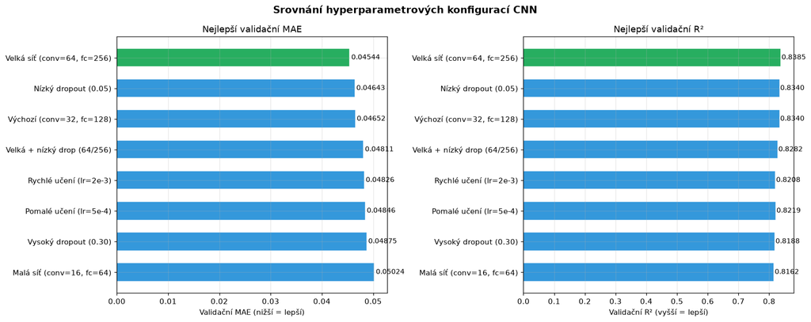

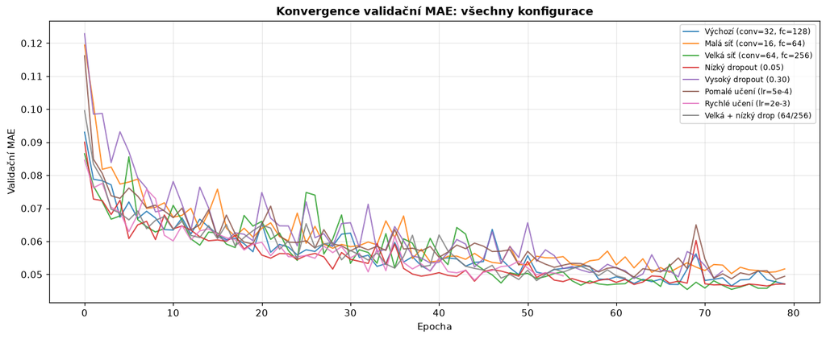

```
Nejlepší konfigurace: C: Velká síť (conv=64, fc=256)
  Val MAE = 0.04544, Val R² = 0.8385
  Parametry: 306,689, Nejlepší epocha: 69
```

### 5.4 Průběh trénování

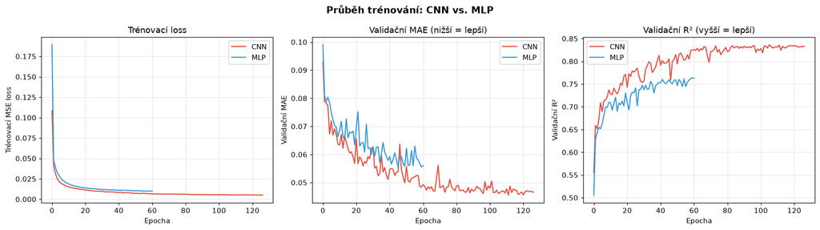

## 6. Evaluace na testovací sadě

Testovací sada (2 500 vzorků) nebyla během trénování ani výběru hyperparametrů použita. Nyní porovnáme:

1. **Multi-Branch CNN** – hlavní model tohoto úkolu
2. **Baseline MLP** – feed-forward neuronová síť
3. **Náhodný les** – nejlepší klasický model z HW3
4. **Gradient Boosting** – druhý nejlepší z HW3
5. **Ridge** – lineární baseline z HW2
6. **Dummy (průměr)** – naivní baseline

|  | Model | Typ | Train MAE | Test MAE | Test RMSE | Test R² | Čas (s) |
| --- | --- | --- | --- | --- | --- | --- | --- |
| 1 | Náhodný les | Klasický | 0.0304 | 0.0439 | 0.0743 | 0.8457 | 4.8 |
| 2 | Multi-Branch CNN | Neuronová síť | 0.0379 | 0.0462 | 0.0769 | 0.8348 | 305.3 |
| 3 | Gradient Boosting | Klasický | 0.0486 | 0.0528 | 0.0839 | 0.8037 | 9.6 |
| 4 | Baseline MLP | Neuronová síť | 0.0543 | 0.0593 | 0.0979 | 0.7324 | 28.1 |
| 5 | Ridge | Klasický | 0.0730 | 0.0761 | 0.1152 | 0.6298 | 0.1 |
| 6 | Baseline (průměr) | Klasický | 0.1426 | 0.1444 | 0.1893 | -0.0006 | 0.1 |

## 7. Vizualizace výsledků

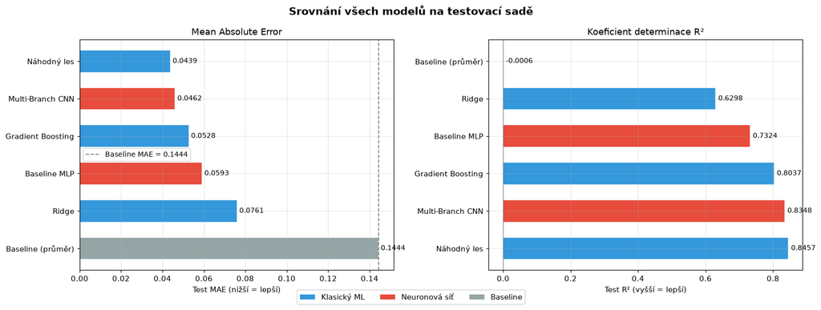

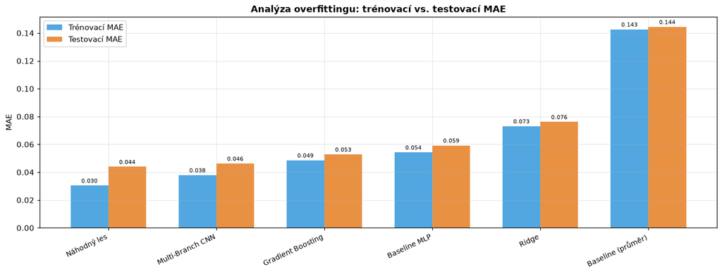

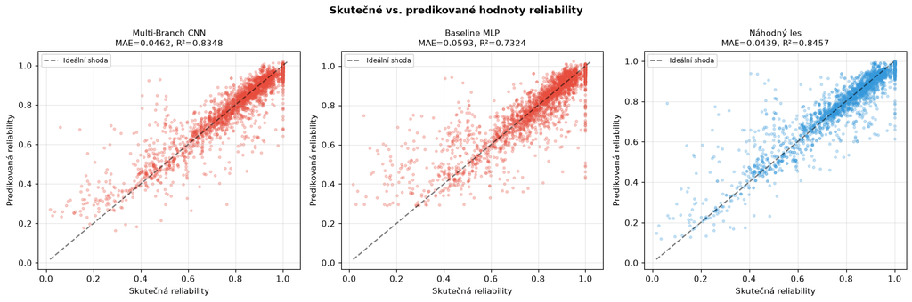

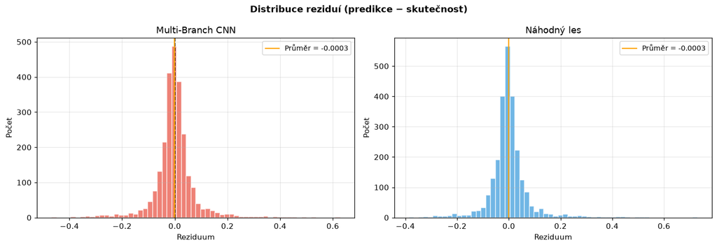

## 8. Diskuze výsledků

### 8.1 Výkonnost Multi-Branch CNN

Multi-Branch CNN dosáhl testovacího **MAE = 0.0462** a **R² = 0.8348**, čímž se umístil na **2. místě** ze všech testovaných modelů – těsně za Náhodným lesem (MAE = 0.0439, R² = 0.8457) a výrazně před Gradient Boostingem (MAE = 0.0528). Konvoluční architektura se sémantickým seskupením příznaků (původní obvod, transpilovaný obvod, hardwarový šum) umožňuje modelu zachytit lokální vzory v rámci každé skupiny příznaků.

Klíčové pozorování: konvoluční filtry s kernel size = 3 hledají trojice příznaků v rámci sémanticky příbuzných skupin. V hardwarové skupině to může zachytit interakci mezi `readout_error`, `single_qubit_gate_error` a `two_qubit_gate_error`; v obvodové skupině mezi `circuit_depth`, `num_cx` a `entanglement_density`.

### 8.2 CNN vs. MLP – přínos konvoluční struktury

Srovnání Multi-Branch CNN (MAE = 0.0462) s baseline MLP (MAE = 0.0593) ukazuje **zlepšení o 22 %** díky konvoluční struktuře a sémantickému seskupení příznaků. CNN má sice více parametrů (77 569 vs. 14 721), ale hlavní rozdíl je architektonický – konvoluce extrahují lokální vzory v rámci skupin příznaků, zatímco MLP pracuje se všemi příznaky najednou bez jakékoli struktury.

Na R² metrice je rozdíl ještě výraznější: CNN dosahuje 0.8348, zatímco MLP pouze 0.7324 – CNN vysvětluje o 10 procentních bodů více variance. Toto potvrzuje, že sémantické seskupení příznaků a konvoluční zpracování přináší reálnou výhodu.

### 8.3 Experimenty s hyperparametry

Systematicky jsme otestovali 8 konfigurací CNN s různými hodnotami kapacity sítě, dropout a learning rate. Výsledky seřazené podle validační MAE:

[output not shown]

**Klíčová zjištění z experimentů:**

1. **Kapacita sítě je nejdůležitější faktor.** Velká síť (C: conv=64, fc=256) dosáhla nejnižší MAE 0.04544, zatímco malá síť (B: conv=16, fc=64) nejhorší MAE 0.05024. Rozdíl činí 10 %, přestože velká síť má 15× více parametrů. Dataset je dostatečně velký (20k řádků), aby větší model nepřetrénoval.
2. **Dropout má překvapivě malý vliv.** Konfigurace s dropout 0.05, 0.15 i 0.30 dosáhly velmi podobných výsledků (MAE 0.04643–0.04875). BatchNorm a early stopping poskytují dostatečnou regularizaci i bez silného dropoutu.
3. **Výchozí learning rate 1e-3 je robustní.** Rychlejší (2e-3) i pomalejší (5e-4) learning rate vedly k mírnému zhoršení. ReduceLROnPlateau scheduler efektivně adaptuje lr během trénování.
4. **Kombinovaná konfigurace H nepřekonala čistou velkou síť C.** Ačkoliv H měla stejnou kapacitu jako C, nižší dropout (0.10) a pomalejší lr (5e-4) vedly k horšímu výsledku (MAE 0.04811 vs. 0.04544). Vyšší lr umožňuje rychlejší konvergenci do lepšího optima.

### 8.4 Neuronové sítě vs. klasické modely

Ensemble metody (Náhodný les, Gradient Boosting) jsou na tabulkových datech tradičně velmi silné. Z výsledků vyplývá:

- **Multi-Branch CNN překonal Gradient Boosting** (MAE 0.0462 vs. 0.0528), což je pozoruhodné – CNN obvykle na tabulkových datech zaostává za gradientním boostingem.
- **Náhodný les zůstává nejlepší** (MAE 0.0439), ale rozdíl oproti CNN je minimální (0.0023, tedy ~5 %).
- CNN přináší **interpretovatelnou strukturu**: vidíme, které skupiny příznaků model zpracovává, a konvoluční filtry mají jasný význam.
- **Ridge regrese** (MAE 0.0761) je o 65 % horší než CNN – nelineární modely jsou pro tento dataset jednoznačně lepší.

### 8.5 Overfitting

Z grafu analýzy overfittingu pozorujeme:

- **Multi-Branch CNN**: Trénovací MAE = 0.0379, testovací MAE = 0.0462 (poměr 1.22). Mírný overfitting, zmírněný regularizací.
- **Baseline MLP**: Trénovací MAE = 0.0543, testovací MAE = 0.0593 (poměr 1.09). Nejmenší overfitting díky nízké kapacitě modelu.
- **Náhodný les**: Trénovací MAE = 0.0304, testovací MAE = 0.0439 (poměr 1.44). Nejvyšší overfitting, ale stále nejlepší testovací výkon.

Regularizační techniky v CNN:

- **Dropout** (p=0.15) v plně propojených vrstvách
- **BatchNorm** stabilizuje trénování a působí jako implicitní regularizátor
- **Early stopping** zastavilo trénování v epochě 127 (z max 150) při validační MAE = 0.04554
- **Weight decay** (L2 regularizace) v AdamW optimizátoru
- **Learning rate scheduling** (ReduceLROnPlateau) postupně snížil lr z 1e-3 na 6.3e-5

### 8.6 Vyplatí se složitost neuronové sítě?

Pro tento dataset je odpověď **podmíněná**:

**Ano**, pokud:

- Potřebujeme end-to-end diferencovatelný model (např. pro integraci do většího pipeline)
- Chceme model snadno rozšiřitelný o nové typy vstupů (sekvenční data, grafy)
- Dataset by se zvětšil – neuronové sítě škálují lépe s objemem dat
- Zajímá nás strukturovaný pohled na data (které skupiny příznaků jsou důležité)

## 9. Shrnutí a závěr

### Hlavní výsledky

| # | Model | Test MAE | Test RMSE | Test R² | Typ |
| --- | --- | --- | --- | --- | --- |
| 1 | Náhodný les | 0.0439 | 0.0743 | 0.8457 | Ensemble (Bagging) |
| 2 | **Multi-Branch CNN** | **0.0462** | **0.0769** | **0.8348** | **Neuronová síť** |
| 3 | Gradient Boosting | 0.0528 | 0.0839 | 0.8037 | Ensemble (Boosting) |
| 4 | Baseline MLP | 0.0593 | 0.0979 | 0.7324 | Neuronová síť |
| 5 | Ridge | 0.0761 | 0.1152 | 0.6298 | Lineární |
| 6 | Baseline (průměr) | 0.1444 | 0.1893 | −0.0006 | Naivní |

### Experimenty s hyperparametry

Otestovali jsme 8 konfigurací CNN lišících se kapacitou sítě, dropout a learning rate. Nejlepší konfigurace **C: Velká síť (conv=64, fc=256)** dosáhla validační MAE = 0.04544 (R² = 0.8385). Experimenty ukázaly, že:

- **Kapacita sítě** má největší vliv na výkon (rozptyl MAE 0.045–0.050)
- **Dropout** a **learning rate** jsou méně citlivé díky BatchNorm a ReduceLROnPlateau scheduleru
- Výchozí konfigurace (conv=32, fc=128, dropout=0.15, lr=1e-3) je robustní volba i bez dalšího ladění

*Notebook byl spuštěn celý od začátku: `Kernel → Restart & Run All`*